# CHAPTER C6

複合形状の局所座屈応力

## C6.1 はじめに

薄い平板は、座屈応力が比較的低いため、圧縮荷重を支持するのには非効率である。しかし、この弱点や欠点は、平板をアングル、チャンネル、Z型などの複合形状に成形することで大幅に改善することができる。また、多くの複合形状のほとんどは、押出成形プロセスによって製造することも可能である。成形部材や押出部材は飛行体構造に広く使用されているため、これらの部材の圧縮強度を計算する方法が必要となる。

## C6.2 等フランジ要素の圧縮座屈応力

第5章の式 (C5.1) より、長いフランジの座屈圧縮応力は、

$$\sigma_{cr} = \frac{k_c \pi^2 E}{12(1-
u_e^2)} \left(\frac{t}{b}\right)^2$$

第5章の Fig. C5.2 より、 $k_c = .43$ であるため、

$$\sigma_{cr} = \frac{0.43 \pi^2 E}{12(1-0.3^2)}
\left(\frac{t}{b}\right)^2 = 0.388 E \left(\frac{t}{b}\right)^2 \quad -
- - \text{C6.1}$$

もし座屈応力が比例限度応力を超える場合は、塑性効果を考慮するために第5章の Fig. C5.7 を使用する。

成形可能な最も単純な等フランジ部材はアングル形状である。等しいフランジを持つ他の形状には、Fig. C6.1 に示すように、Tセクションおよび十字セクションがある。

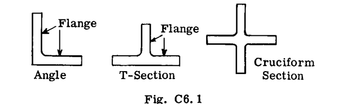

Fig. C6.1

成形アングルの場合、フランジ幅 $b$ は隣接する脚の中心線まで延びるが、押出アングルの場合、幅 $b$ は隣接するフランジまたは脚の内側の端まで延びる。

これらのセクションは、Fig. C6.2 のアングルセクションで示されているように、長いフランジのグループとして考えることができる。セクションを構成するフランジはサイズが等しいため、各フランジは同じ応力で座屈する。したがって、各フランジは互いに拘束し合うことができず、その結果、Fig. C6.2 に示すように、各フランジはフランジ接合部に沿って単純支持されていると仮定できる。

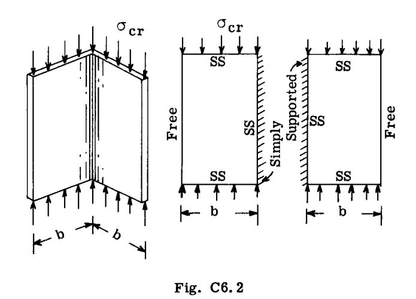

Fig. C6.2

## C6.3 単純なフランジ・ウェブ要素の圧縮座屈応力

最も一般的なフランジ・ウェブ構造形状は、チャンネル、Z型、およびハットセクションである。フランジは1つの非負荷縁が自由端であるのに対し、ウェブは自由な非負荷縁を持たないため、ウェブとフランジの境界には未知の拘束が存在する。Fig. C6.3 は、Zセクションを2つのフランジ板要素と1つのウェブ板要素に分解した様子を示している。

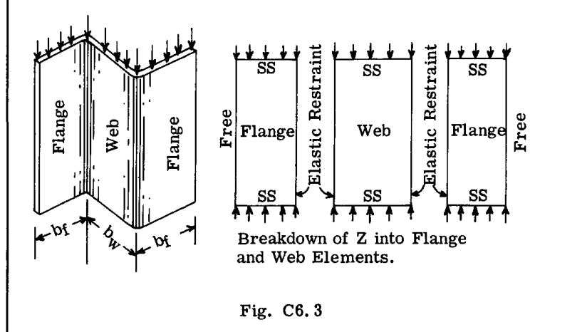

Fig. C6.3

ウェブおよびフランジ要素の座屈強度は、2つの要素間の境界拘束に依存する。もし、この未知の拘束が、第5章で提示されているような既知の回転拘束 $\epsilon$ で表すことができれば、座屈係数は第5章のチャートから求めることができる。各要素の座屈応力が得られれば、臨界座屈応力は2つのうち小さい方となる。座屈応力に基づく座屈荷重は、破壊荷重ではない。なぜなら、局所的な破壊やクリップリングが発生する前に、コーナー領域の材料によってさらに多くの荷重を支持できるからである。成形および押出形状の局所クリップリングについては、第7章で取り扱う。

モーメント分配法または逐次解析手順を用いて、いくつかの研究により、チャンネル、Z、H、角形管などの単純な形状に対するウェブとフランジ要素間の拘束因子が決定され、そのような形状の設計チャートが作成されている（文献1〜5を参照）。

## C6.4 一部のごく一般的な複合ウェブ・フランジ形状の局所座屈応力設計チャート

Fig. C6.4 から Fig. C6.7 までは、チャンネル、Z、H、角形管、およびハット型セクションの局所座屈応力を決定するためのチャートを示している。成形セクションの場合、幅 $b$ は隣接する要素の中心線まで延び、押出セクションの場合、幅 $b$ は隣接する要素の内側の端まで延びる。

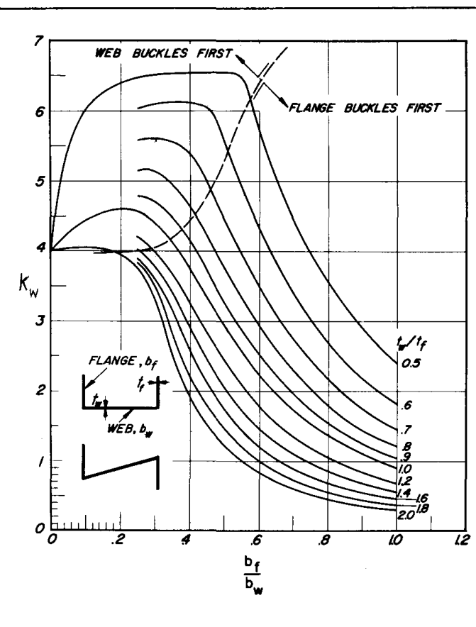

Fig. C6.4

$$\sigma_{cr} = \frac{k_w \pi^2 E}{12(1-
u_e^2)} \left(\frac{t_w}{b_w}\right)^2$$

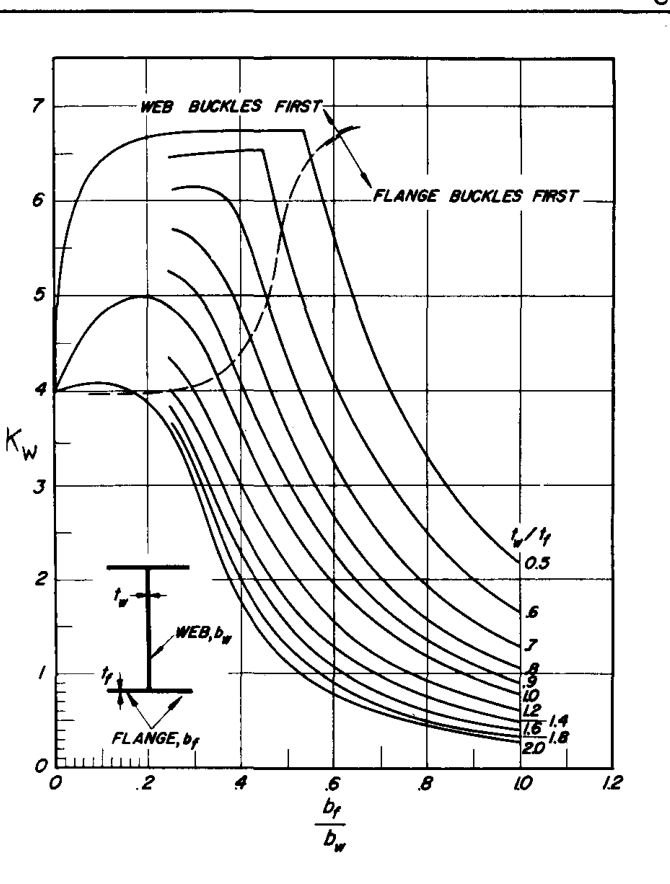

Fig. C6.5

$$\sigma_{cr} = \frac{k_w \pi^2 E}{12(1-
u_e^2)} \left(\frac{t_w}{b_w}\right)^2$$

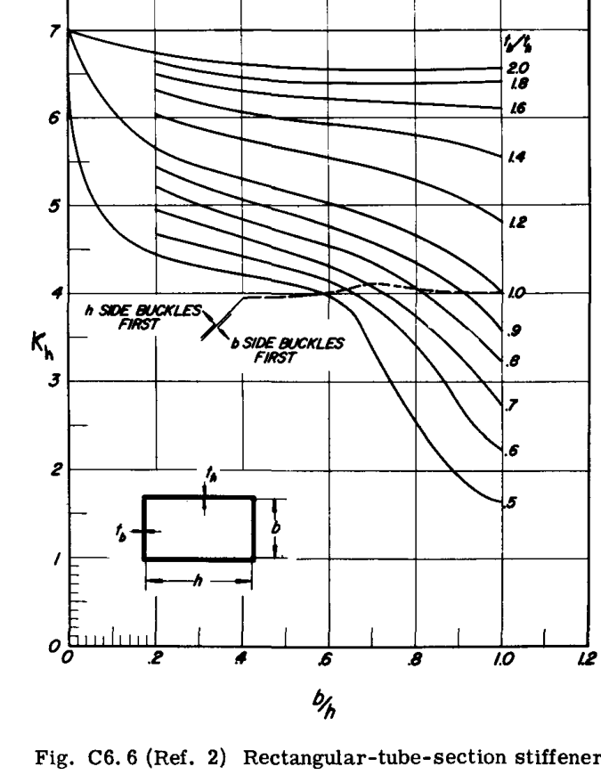

Fig. C6.6

$$\sigma_{cr} = \frac{k_h \pi^2 E}{12(1-
u_e^2)} \left(\frac{t_h}{h}\right)^2$$

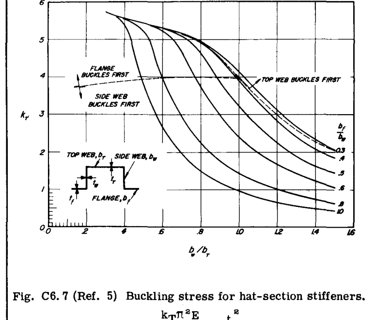

Fig. C6.7

$$t = t_f = t_w = t_T; \quad \sigma_{cr} = \frac{k_T \pi^2 E}{12(1-
u_e^2)} \left(\frac{t}{b_T}\right)^2$$

## C6.5 チャートの使用例題

### 問題 1

Fig. (a) に示すZセクションは、アルミニウム合金 2024-T3 板から成形されている。部材のいずれかの要素で局所座屈が開始される圧縮応力はいくらか。

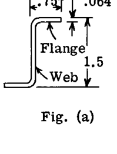

Fig. (a)

**解答:-**

$$b_w = 1.5 - .064 = 1.436$$

$$_f = 0.75 - .032 = 0.718$$

$$b_f/b_w = 0.718/1.436 = .50$$

$$t_w/t_f = .064/.064 = 1.0$$

Fig. C6.4 より、 $k_w = 2.9$ を読み取る。

$$\sigma_{cr} = \frac{k_w \pi^2 E}{12(1-
u_e^2)} \left(\frac{t_w}{b_w}\right)^2 \quad - - - - - - - - (A)$$

$$\sigma_{cr} = \frac{2.9 \pi^2 \times 10,700,000}{12(1-.3^2)}
\left(\frac{.064}{1.436}\right)^2 = 56100 \text{ psi}$$

この応力は材料の比例限度応力を超えているため、塑性補正を行う必要がある。座屈はフランジで発生する。

第B1章の Table B1.1 より、2024-T3 アルミニウム合金について、 $\sigma_{0.7} = 39000$ および $n = 11.5$ を得る。

Fig. C6.4 (文献 4) でカバーされている形状の塑性補正については、片縁自由フランジの塑性補正を精度よく使用できる。したがって、第5章の Fig. C5.7 のチャートを用いて塑性効果を補正できる。

Fig. C5.7 の下部目盛りのパラメータは、式 (A) を $\sigma_{0.7}$ で除したものであり、 $56100/39000 = 1.44$ となる。この値と $n = 11.5$ の曲線を使用すると、Fig. C5.7 から $\sigma_{cr}/\sigma_{0.7} = 1.02$ と読み取れる。

したがって、局所座屈応力は次のようになる。

$$\sigma_{cr} = 39000 \times 1.02 = 39800 \text{ psi}$$

### 問題 2

問題1の部材が 300°F の温度に 2 時間さらされた場合、局所座屈応力はいくらになるか。

**解答:-**

Table B1.1 より、この温度条件に対して、

$$\sigma_{0.7} = 35700, \quad E_c = 10,300,000, \quad n = 15$$

$$\frac{k_w \pi^2 E}{12(1-
u_e^2)(\sigma_{0.7})} \left(\frac{t_w}{b_w}\right)^2 = \frac{2.9 \pi^2
\times 10,300,000}{12(1-.3^2)(35700)} \left(\frac{.064}{1.436}\right)^2
= 1.51$$

この値を Fig. C5.7 の下部目盛りで使用し、 $n = 15$ の曲線から、 $\sigma_{cr}/\sigma_{0.7} = 1.03$ と読み取る。 したがって、 $\sigma_{cr} = 1.03 \times 35700 = 36800 \text{ psi}$ となる。

### 問題 3

問題1と同様とするが、材料をチタン Ti-8Mn シートに変更する。

**解答:-**

Table B1.1 より、この材料について以下を得る。 $E_c = 15,500,000$ , $\sigma_{0.7} = 119500$ , $n = 13.7$ 。

$$\sigma_{cr} = \frac{2.9 \pi^2 \times 15,500,000}{12(1-.3^2)}
\left(\frac{.064}{1.436}\right)^2 = 81200 \text{ psi}$$

この応力は比例限度応力に近いため、塑性補正を行うとしても小さくて済む。

$$\sigma_{cr}/\sigma_{0.7} = 81200/119500 = .68$$

Fig. C5.7 より、 $n = 13.7$ の曲線を使用すると、 $\sigma_{cr}/\sigma_{0.7} = .68$ と読み取れる。したがって、 $\sigma_{cr} = 119500 \times 0.68 = 81300 \text{ psi}$ となり、塑性補正は必要ない。

### 問題 4

長方形管が Fig. (b) に示す寸法を持っている。これはアルミニウム合金 2014-T6 から押出成形されたものである。局所圧縮座屈応力を決定せよ。

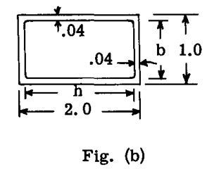

Fig. (b)

**解答:-**

$$b = 1 - .08 = .92$$

$$h = 2 - .08 = 1.92$$

$$b/h = .92/1.92 = .479$$

$$t_b/t_h = 1.0$$

Fig. C6.6 より、 $k_h = 5.2$ と読み取る。

$$\sigma_{cr} = \frac{5.2 \pi^2 \times 10,700,000}{12(1-.3^2)}
\left(\frac{.04}{1.92}\right)^2 = 21900 \text{ psi}$$

Fig. C6.6 に示すように、座屈は管の $h$ 側で発生する。計算された座屈応力は比例限度応力を下回っているため、塑性補正は不要である。

### 問題 5

問題4と同様とするが、 $h$ 側の厚さを .072 に変更し、 $b$ 側の厚さは .04 のままとする。

**解答:-**

$$b = 1 - .144 = .856$$

$$h = 2 - .08 = 1.92$$

$$b/h = .856/1.92 = .446$$

$$t_b/t_h = .04/.072 = .555$$

Fig. C6.6 より、 $k_h = 4.3$ 。

$$\sigma_{cr} = \frac{4.3 \pi^2 \times 10,700,000}{12(1-.3^2)}
\left(\frac{.072}{1.92}\right)^2 = 58600 \text{ psi}$$

この応力は比例限度応力を超えているため、塑性補正が必要である。(文献 4) には可塑性補正の値が示されていないが、やや保守的な補正として、固定支持された長いフランジに対する補正を推奨している。この塑性補正は、Fig. C6.7 に示すハット形状にも使用されるべきである。

したがって、塑性効果の補正には第5章の Fig. C5.8 を使用できる。

Table B1.1 より、今回の材料に対して $\sigma_{0.7} = 53000$ および $n = 18.5$ を得る。

Fig. C5.8 の下部目盛りのパラメータ値は、 $\sigma_{cr}/\sigma_{0.7} = 58600/53000 = 1.10$ である。

Fig. C5.8 から、 $n = 18.5$ の曲線を使用すると、 $\sigma_{cr}/\sigma_{0.7} = .91$ と読み取れる。したがって、 $\sigma_{cr} = 53000 \times .91 = 48100 \text{ psi}$ となる。

このように、管の長辺の厚さを .04 から .072 に変更することで、座屈応力は 21900 から 48100 psi に増加した。

長方形管の設計において、設計者は両面で同時に座屈が発生するように長辺と短辺の両方の肉厚を選択する必要があり、これにより座屈強度に対して最も軽量なセクションが得られる。

この章で前述したように、局所座屈を引き起こす部材上の荷重は、短尺部材の破壊荷重または最大荷重ではない。この局所破壊またはクリップリング応力については、次の章で取り扱う。座屈応力は非弾性応力範囲に低下する可能性があるため、荷重を取り除いても座屈は完全には消失しない。制限荷重または実用荷重は永久的な歪みなしに支持されなければならないため、局所座屈がいつ開始するかを知ることが重要である。人間を乗せないミサイルや宇宙飛行体では、制限荷重に対する安全率は航空機に比べてかなり小さいため、局所座屈強度と局所破壊強度の差が設計において重要となる。

## C6.6 縦圧縮を受ける補強平板の座屈

超音速航空機においては、座屈した表面が翼の周りの空気流の空気力学的特性に影響を及ぼす可能性があるため、外板、特に翼上の外板が飛行条件下で座屈しないことが重要である。したがって、飛行条件下でそのような座屈が発生しないように設計するためには、外板またはその補強部材が最初に座屈する時期を知ることが重要である。

Gallaher と Boughan (文献 6) および Boughan と Baab (文献 7) は、理想化されたウェブ、Z、およびT補強板の局所座屈係数を決定した。彼らの研究結果は Figures C6.8 から C6.12 に示されており、(文献 4) から引用された。板または補強材の初期局所座屈応力は、次の式で与えられる。

$$\sigma_{cr} = \frac{k_s \pi^2 E}{12(1-
u_e^2)} \left(\frac{t_s}{b_s}\right)^2 \quad - - - - - - - - (B)$$

もし座屈応力が材料の比例限度応力を超えている場合は、第5章の Fig. C5.8 を使用して塑性効果の補正を行う。

### チャートの使用例題

Fig. (c) は、理想化されたZセクション補強材を持つ板を示している。材料は 2024-T3 アルミニウム合金である。縦圧縮下での初期座屈応力を決定せよ。

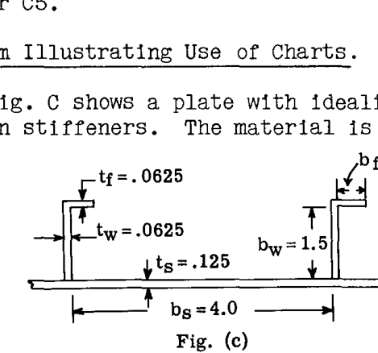

Fig. (c)

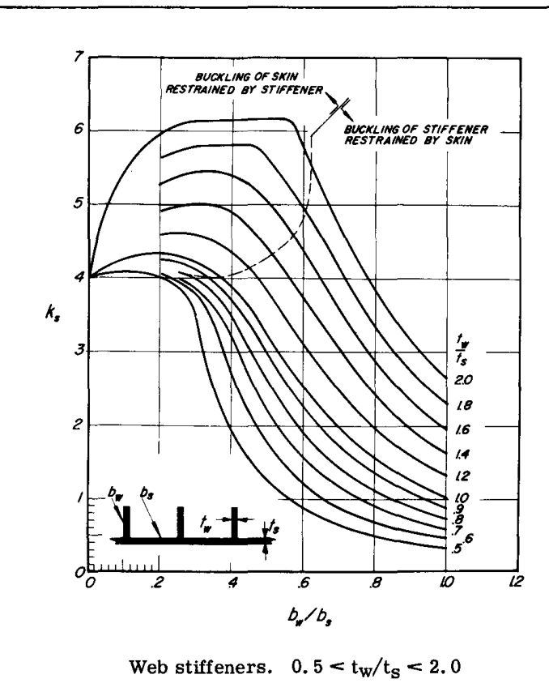

Fig. C6.8

$$\sigma_{cr} = \frac{k_s \pi^2 E}{12(1-
u_e^2)} \left(\frac{t_s}{b_s}\right)^2$$

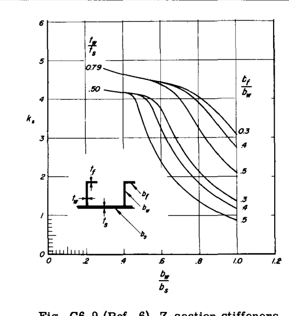

Fig. C6.9

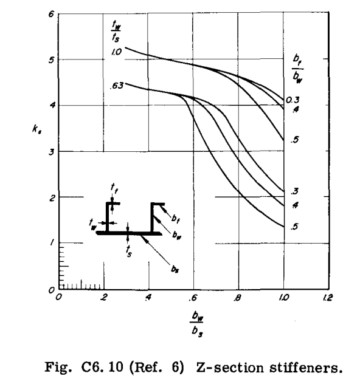

Fig. C6.10

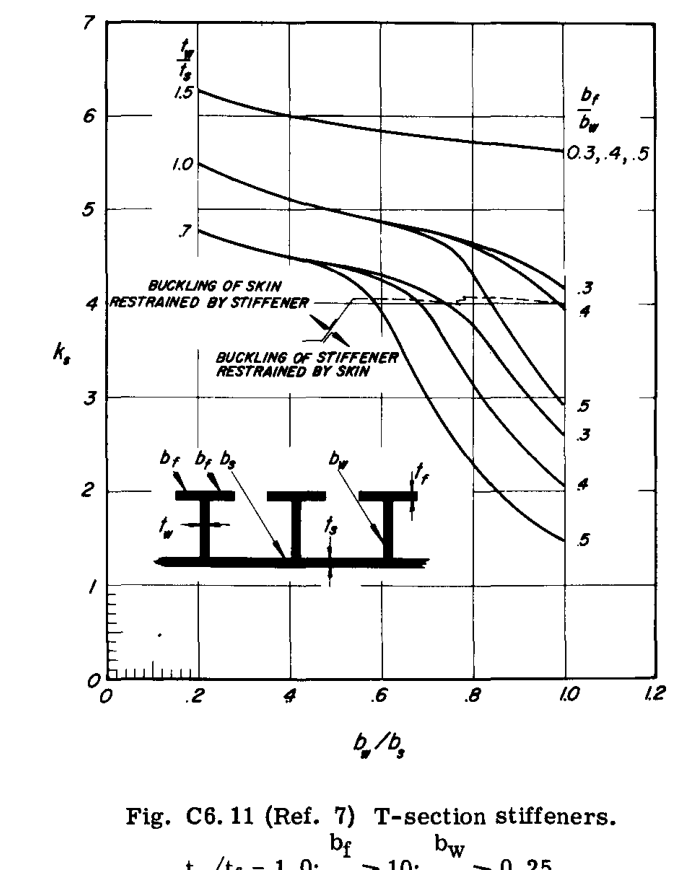

Fig. C6.11

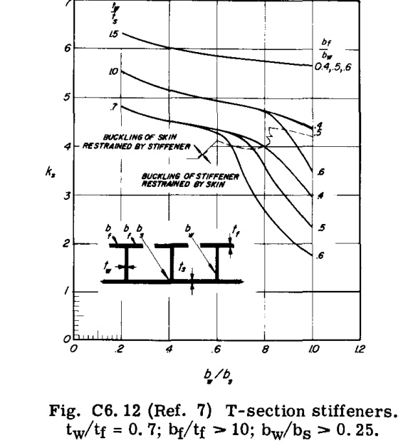

Fig. C6.12

$$\frac{b_f}{b_w} = \frac{0.5}{1.5} = 0.333, \quad \frac{b_w}{b_s} =
\frac{1.5}{4.0} = .375$$

$$\frac{t_w}{t_s} = \frac{.0625}{0.125} = .50$$

上記の3つの値を使用し、Fig. C6.9 を参照すると、座屈係数 $k_s$ は 4.2 と読み取れる。式 (B) に代入すると、

$$\sigma_{cr} = \frac{4.2 \pi^2 \times 10,700,000}{12(1-.3^2)}
\left(\frac{.125}{4.0}\right)^2 = 39800 \text{ psi}$$

この応力は明らかに比例限度応力を超えているため、塑性効果のチェックを行う。この効果のために、第5章の Fig. C5.8 を使用する。

今回の 2024-T3 材料について、第B1章の Table B1.1 から、 $\sigma_{0.7} = 39000$ および形状パラメータ $n = 11.5$ を得る。

Fig. C5.8 の下部目盛りパラメータは、式 (B) を $\sigma_{0.7}$ で除したものであるため、 $39800/39000 = 1.02$ に等しい。この値と Fig. C5.8 の $n = 11.5$ の曲線を使用すると、左側の目盛りから $\sigma_{cr}/\sigma_{0.7} = .86$ と読み取れる。したがって、座屈応力 $\sigma_{cr} = .86 \times 39000 = 33600 \text{ psi}$ となる。

## 参考文献

1. Lundquist, Stowell and Schuette: Principles of Moment Distribution Applied to Stability of Structures Composed of Bars and Plates. NACA WRL-326, 1943.
2. Kroll, Fisher and Heimerl: Charts for Calculation of the Critical Stress for Local Instability of Columns with I, Z, Channel and Rectangular Tube Sections. NACA WRL-429, 1943.
3. Kroll: Tables of Stiffness and Carry-over Factor for Flat Rectangular Plates Under Compression: NACA WRL-398, 1943.
4. Becker: Handbook of Structural Stability. Part II. Buckling of Composite Elements. NACA TN.3782, July 1957.
5. Van Der Maas: Charts for the Calculation of the Critical Compressive Stress for Local Instability of Columns with Hat Sections. Jour. Aero. Sci. Vol. 21, June 1954.
6. Gallaher and Boughan: A Method for Calculating the Compressive Strength of Z Stiffened Panels that Develop Local Instability. NACA TN.1482, 1947.
7. Boughan and Baab: Charts for Calculating the Critical Compressive Stress for Local Instability of Idealized T Stiffened Panels. NACA WRL-204, 1944.